# Evaluating the effects of tracking devices on survival, breeding success, behaviour, and condition of a small, partially migratory shorebird

Supplementary Material A: Journal of Avian Biology 10.1002/jav.03490

Authors

Affiliations

[Luke Eberhart-Hertel](https://www.bi.mpg.de/person/115852/2867)

Department of Ornithology, Max Planck Institute for Biological Intelligence, Eberhard-Gwinner Straße 7, 82319 Seewiesen, Germany

Emma Williams

Fauna Science Team, Department of Conservation Christchurch Office, Christchurch Mail Centre, Private Bag 4715, Christchurch, 8140, New Zealand

Ailsa McGilvary-Howard

Kaikōura Banded Dotterel Project, 1 Maui Street, Kaikōura, New Zealand

Ted Howard

Kaikōura Banded Dotterel Project, 1 Maui Street, Kaikōura, New Zealand

Tony Habraken

Port Waikato Banded Dotterel Project, Port Waikato, New Zealand

Colin O`Donnell

Fauna Science Team, Department of Conservation Christchurch Office, Christchurch Mail Centre, Private Bag 4715, Christchurch, 8140, New Zealand

Clemens Küpper

Behavioural Genetics and Evolutionary Ecology, Max Planck Institute for Biological Intelligence, Eberhard-Gwinner Straße 5, 82319 Seewiesen, Germany

Bart Kempenaers

Department of Ornithology, Max Planck Institute for Biological Intelligence, Eberhard-Gwinner Straße 7, 82319 Seewiesen, Germany

Published

July 2, 2025

## Prerequisites

### R packages

```r
# Set a CRAN mirror before installing packages
options(repos = c(CRAN = "https://cloud.r-project.org"))

# a vector of all the packages needed in the project
packages_required_in_project <-
  c("apis", "BaSTA", "brms", "broom.mixed", "colorspace", "corrplot", "data.table",
    "effects", "elevatr", "geosphere", "ggblend", "ggeffects", "ggmap",
    "ggnewscale", #"ggsn",
    "giscoR", "glue", "googlesheets4", "gt", "gtsummary",
    "here", "hms", "lme4", "lubridate", "mapview", "mgcv", "multcomp", "MuMIn", "nnet",
    "partR2", "patchwork", "RColorBrewer", "readxl", "remotes", "RMark", "rnaturalearth",
    "rptR", "scales", "sf", "showtext", "smatr", "sp", "stringr", "tidybayes",
    "tidyterra", "tidyverse", "adehabitatLT", "magrittr", "MASS", "leaflet", "shiny",
    "leaflet.extras", "ggrepel", "ggpmisc", "grid", "knitr", "kableExtra")

# of the required packages, check if some need to be installed
new.packages <-
  packages_required_in_project[!(packages_required_in_project %in%
                                   installed.packages()[,"Package"])]

# install all packages that are not locally available
if(length(new.packages)) install.packages(new.packages)

# load all the packages into the current R session
lapply(packages_required_in_project, require, character.only = TRUE)
```

### Custom functions

```r
# function that does the opposite of "%in%"
`%!in%` = Negate(`%in%`)

# scaled mass index calculation from Peig and Green (2009)
# https://doi.org/10.1111/j.1365-2435.2010.01751.x
scaledMassIndex <-
  function(x, y, x.0 = mean(x)) {
    logM.ols <- lm(log(y) ~ log(x))
    logM.rob <- rlm(log(y) ~ log(x), method = "M")
    b.msa.ols <- coef(sma(log(y) ~ log(x)))[2]
    b.msa.rob <- coef(sma(log(y) ~ log(x), robust = T))[2]
    SMI.ols <- y * (x.0 / x) ^ b.msa.ols
    SMI.rob <- y * (x.0 / x) ^ b.msa.rob
    res <- data.frame(SMI.ols, SMI.rob, x, y)
    pred.DT <-
      data.table(x = seq(min(x), max(x), length = 100)) %>%
      .[, y.ols := predict(logM.ols, newdata = .) %>% exp] %>%
      .[, y.rob := predict(logM.rob, newdata = .) %>% exp]
    attr(res, "b.msa") <- c(ols = b.msa.ols, rob = b.msa.rob)
    return(res)
  }
```

# Body Condition Dynamics

### specify attachment weights

```r
harness = 0.29
colour_band = 0.08
metal_band = 0.16
PTT = 1.8
PTT2 = 2.0
GPS = 1.2
```

## PCA of structural traits

```r
body_traits <-
  read.csv(here("data/body_traits_season.csv"))
```

#### check most relevent structural traits with PCA

```r
body_traits_pca <-
  body_traits %>%
  group_by(ring) %>%
  arrange(measure) %>%
  slice(1) %>%
  ungroup() %>%
  dplyr::select(culmen, tarsus, wing) %>%
  na.omit() %>%
  princomp()

# check the PCA results
summary(body_traits_pca)
```

```
Importance of components:
                          Comp.1     Comp.2     Comp.3
Standard deviation     3.0375002 0.92702190 0.70667715
Proportion of Variance 0.8716353 0.08118619 0.04717851
Cumulative Proportion  0.8716353 0.95282149 1.00000000
```

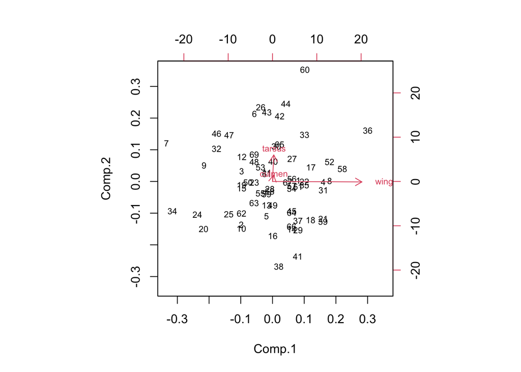

```r
biplot(body_traits_pca, cex = 0.7)
```

```r
loadings(body_traits_pca)
```

```
Loadings:
       Comp.1 Comp.2 Comp.3
culmen         0.232  0.973
tarsus         0.973 -0.232
wing    1.000

               Comp.1 Comp.2 Comp.3
SS loadings     1.000  1.000  1.000
Proportion Var  0.333  0.333  0.333
Cumulative Var  0.333  0.667  1.000
```

```r
# bind PC scores to the original dataframe
body_traits_pca_scores <-
  body_traits %>%
  group_by(ring) %>%
  arrange(measure) %>%
  slice(1) %>%
  bind_cols(., body_traits_pca$scores[, 1], body_traits_pca$scores[, 2], body_traits_pca$scores[, 3]) %>%
  rename(structure_pc1 = `...13`,
         structure_pc2 = `...14`,
         structure_pc3 = `...15`) %>%
  na.omit() %>%
  ungroup()
```

#### check correlations of traits with weight to determine best trait to use for SMI

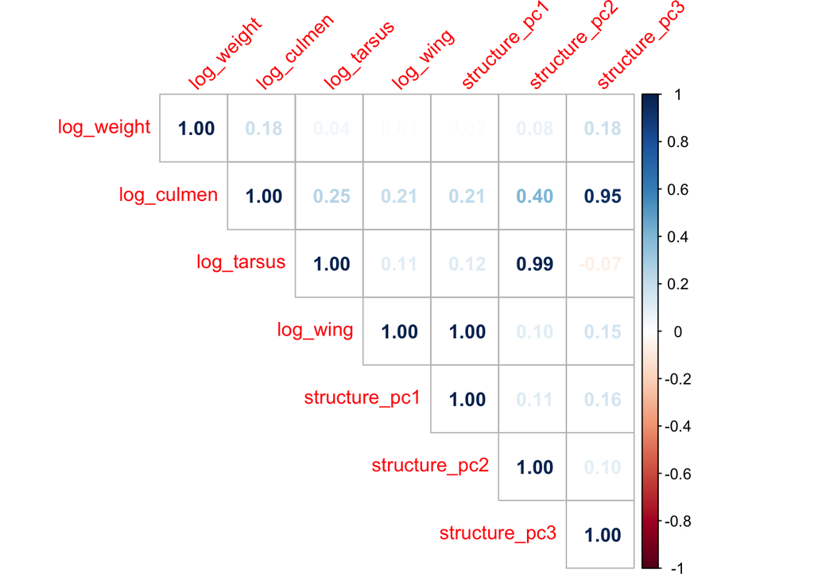

#### visualize the relationship between the principle components and body mass

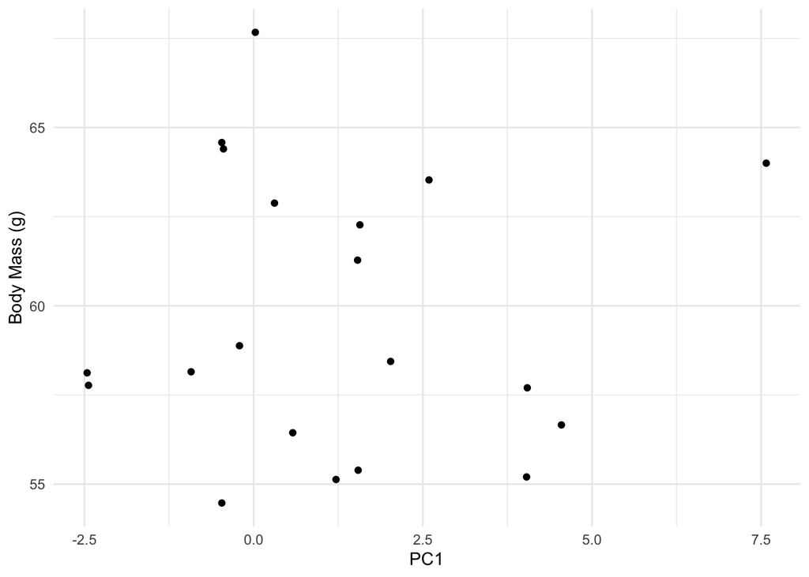

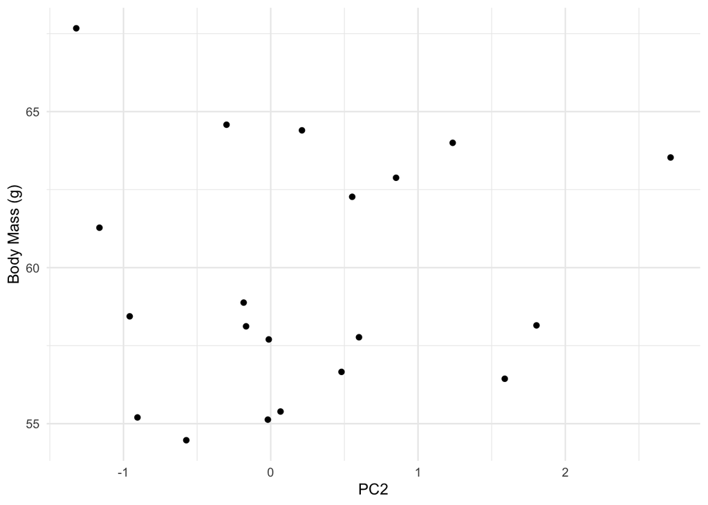

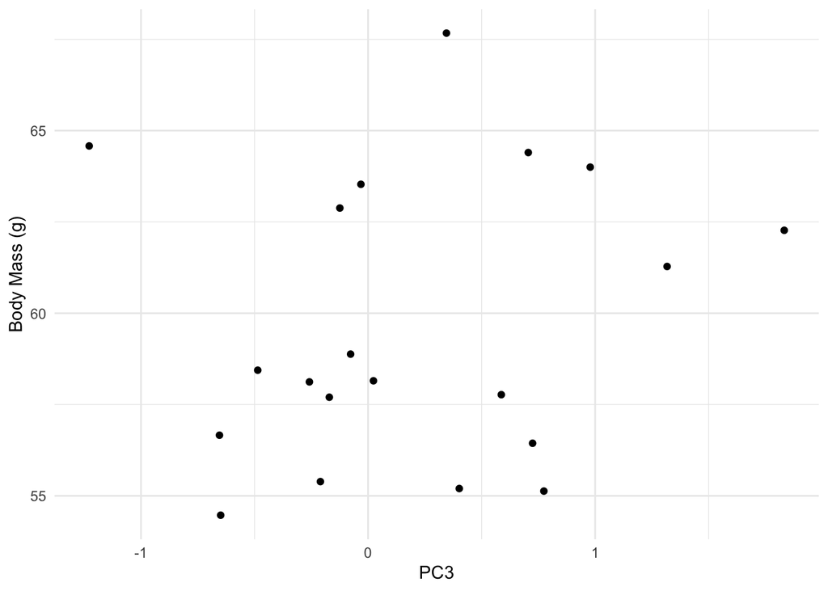

#### visualize the relationship between the wing length and body mass

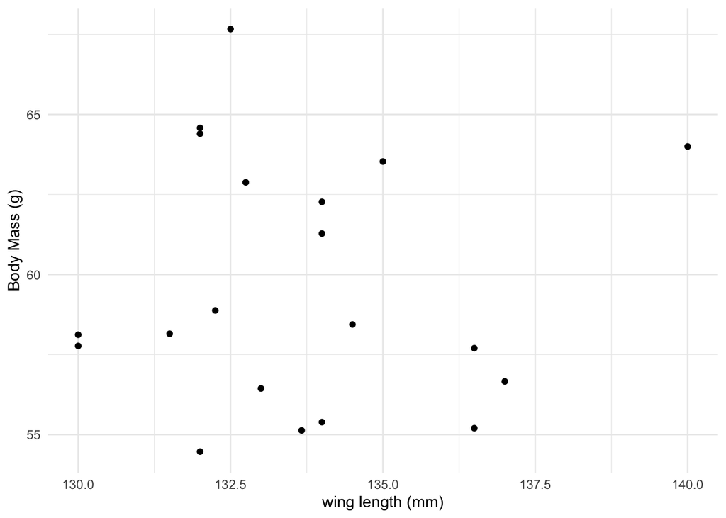

#### visualize the relationship between the tarsus length and body mass

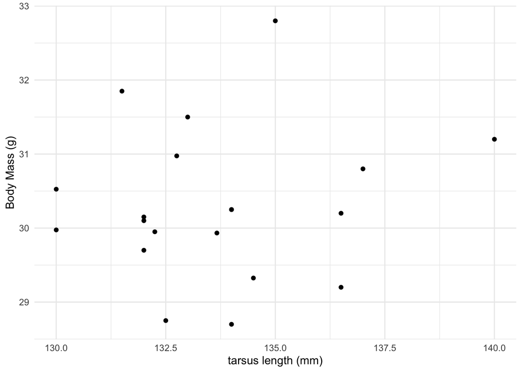

## Scaled Mass Index wrangle

average all repeated measures of structural traits for each bird (i.e., variation within individuals for these traits is assumed to be observer/instrument error)

```r
body_traits_avg <-
  body_traits %>%
  group_by(ring) %>%
  mutate(culmen = mean(culmen, na.rm = TRUE),
         tarsus = mean(tarsus, na.rm = TRUE),
         wing = mean(wing, na.rm = TRUE))
```

#### determine which structural trait to use for the scaled mass index calculation

see text in Peig and Green (2009) after Eq. 2: “…We recommend the use of the single ‘L’ variable which has the strongest correlation with M on a log-log scale, since this is likely to be the L that best explains that fraction of mass associated with structural size” Conclude to use wing for SMI transformation because it has the largest r and based on the PCA investigation above, wing did just as good as PC1 when explaining variation in weight

```r
cor.test(log(body_traits_avg$tarsus), log(body_traits_avg$weight)) # r = 0.130
```

```
    Pearson's product-moment correlation

data:  log(body_traits_avg$tarsus) and log(body_traits_avg$weight)
t = 1.2261, df = 87, p-value = 0.2235
alternative hypothesis: true correlation is not equal to 0
95 percent confidence interval:
 -0.08010378  0.32963699
sample estimates:
      cor
0.1303271
```

```r
cor.test(log(body_traits_avg$wing), log(body_traits_avg$weight)) # r = 0.226
```

```
    Pearson's product-moment correlation

data:  log(body_traits_avg$wing) and log(body_traits_avg$weight)
t = 2.1671, df = 87, p-value = 0.03296
alternative hypothesis: true correlation is not equal to 0
95 percent confidence interval:
 0.01894248 0.41500412
sample estimates:
      cor
0.2263065
```

```r
cor.test(log(body_traits_avg$culmen), log(body_traits_avg$weight)) # r = 0.090
```

```
    Pearson's product-moment correlation

data:  log(body_traits_avg$culmen) and log(body_traits_avg$weight)
t = 0.84253, df = 87, p-value = 0.4018
alternative hypothesis: true correlation is not equal to 0
95 percent confidence interval:
 -0.1205525  0.2927350
sample estimates:
       cor
0.08996281
```

Use scaledMassIndex() function [defined in chunk above] to derive the SMI for each body mass measure (see Eq 2 of Peig and Green (2009))

```r
smi_ <-
  scaledMassIndex(x = body_traits_avg %>%
                    ungroup() %>%
                    dplyr::select(weight, wing) %>%
                    na.omit() %>%
                    pull(wing),
                  y = body_traits_avg %>%
                    ungroup() %>%
                    dplyr::select(weight, wing) %>%
                    na.omit() %>%
                    pull(weight))

body_traits_smi <-
  body_traits_avg  %>%
  filter(!is.na(weight)) %>%
  bind_cols(., smi_) %>%
  dplyr::select(ring, tag_type, tag_type_, treatment_group, measure, SMI.ols, weight, day_of_year, date_diff) %>%
  rename(smi_wing = SMI.ols)
```

inspect relationship between raw body mass and scaled mass index (lines connect repeated measures)

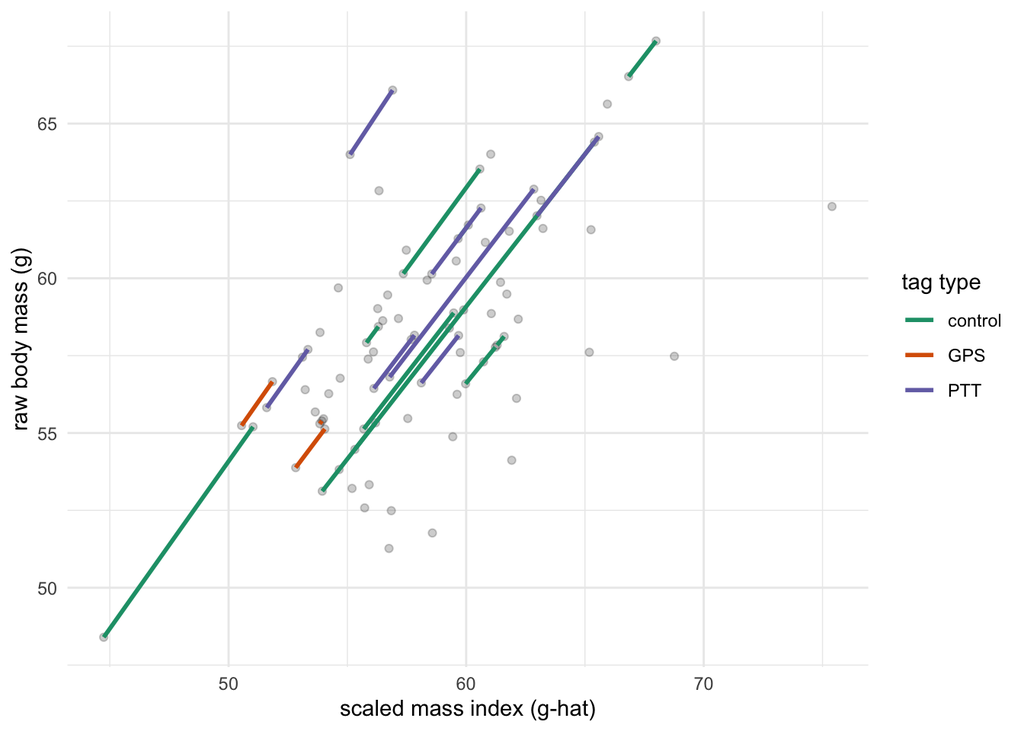

## Scaled Mass Index sequential measures model

#### sample size summary

```
# A tibble: 3 × 2
  tag_type     n
  <chr>    <int>
1 GPS         10
2 PTT         10
3 control     49
```

#### summary of attachment mass

**summary of attachment weights**

*expressed as relative percentage of scaled mass index or raw body mass*

|  |  | 1.2 g GPS (%) | 1.8-2.0 g PTT (%) | only leg bands (%) |
| --- | --- | --- | --- | --- |
| raw body mass |  |  |  |  |
| only tracking device | mean | 2.0 | 3.0 | NA |
|  | median | 2.0 | 3.0 | NA |
|  | min | 1.9 | 2.8 | NA |
|  | max | 2.1 | 3.5 | NA |
|  | sd | 0.0 | 0.1 | NA |
| all attachments | mean | 2.8 | 3.8 | 0.8 |
|  | median | 2.8 | 3.8 | 0.8 |
|  | min | 2.6 | 3.6 | 0.7 |
|  | max | 3.0 | 4.3 | 0.9 |
|  | sd | 0.1 | 0.2 | 0.0 |
| scaled mass index |  |  |  |  |
| only tracking device | mean | 2.0 | 3.1 | NA |
|  | median | 2.0 | 3.0 | NA |
|  | min | 1.8 | 2.7 | NA |
|  | max | 2.3 | 3.6 | NA |
|  | sd | 0.1 | 0.3 | NA |
| all attachments | mean | 2.9 | 3.9 | 0.8 |
|  | median | 2.9 | 3.8 | 0.8 |
|  | min | 2.6 | 3.4 | 0.6 |
|  | max | 3.2 | 4.4 | 0.9 |
|  | sd | 0.2 | 0.3 | 0.0 |

#### sample size summary

```
# A tibble: 3 × 2
  tag_type     n
  <chr>    <int>
1 GPS         10
2 PTT         10
3 control     49
```

### distribution of time differences between repeated measures

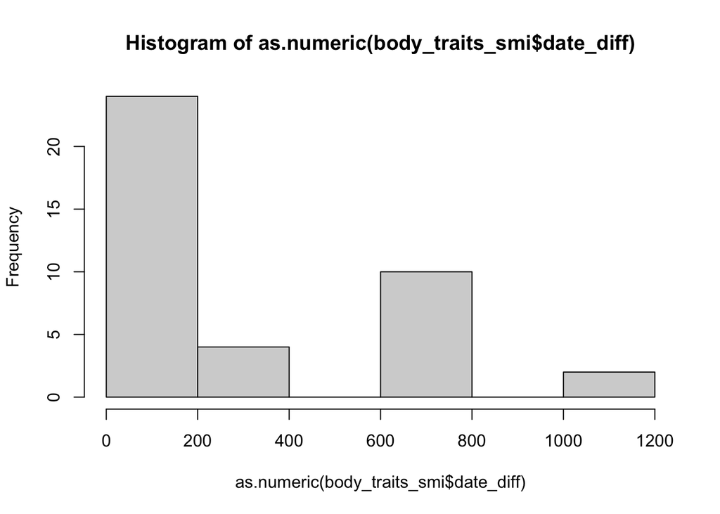

```r
hist(as.numeric(body_traits_smi$date_diff))
```

```r
body_traits_smi %>% filter(!is.na(date_diff)) %>% pull(date_diff) %>% min()
```

```
[1] 2
```

```r
body_traits_smi %>% filter(!is.na(date_diff)) %>% pull(date_diff) %>% max()
```

```
[1] 1097
```

### modelling

```r
smi_wing_lmer_DOY_season <- lme4::lmer(
  smi_wing ~ tag_type * measure + scale(day_of_year) + (1 | ring),
  data = body_traits_smi, REML = TRUE
)
```

### contrast interactive and non-interactive model

```r
smi_wing_lmer_DOY_season_interaction <-
  lmer(smi_wing ~ tag_type * measure + scale(day_of_year) + (1 | ring),
       data = body_traits_smi, REML = FALSE)

smi_wing_lmer_DOY_season_noninteraction <-
  lmer(smi_wing ~ tag_type + measure + scale(day_of_year) + (1 | ring),
       data = body_traits_smi, REML = FALSE)
```

Likelihood Ratio Test for Model Comparison

| term | npar | AIC | BIC | logLik | minus2logL | statistic | df | p.value |
| --- | --- | --- | --- | --- | --- | --- | --- | --- |
| smi_wing_lmer_DOY_season_noninteraction | 8 | 514.554 | 534.464 | -249.277 | 498.554 | NA | NA | NA |
| smi_wing_lmer_DOY_season_interaction | 12 | 521.687 | 551.551 | -248.843 | 497.687 | 0.868 | 4 | 0.929 |

### statistics

```r
# set seed for reproducibility
set.seed(1234)

# Derive confidence intervals of effect sizes from parametric bootstrapping
tidy_smi_wing_lmer_DOY_season <-
  tidy(smi_wing_lmer_DOY_season, conf.int = TRUE, conf.method = "boot", nsim = 1000)

# run rptR to obtain repeatabilities of random effects
rpt_smi_wing_lmer_DOY_season <-
  rpt(smi_wing ~ tag_type * measure + scale(day_of_year) + (1 | ring),
      grname = c("ring", "Fixed"),
      data = body_traits_smi,
      datatype = "Gaussian",
      nboot = 1000, npermut = 1000, ratio = TRUE,
      adjusted = TRUE, ncores = 4, parallel = TRUE)

# run partR2 on each model to obtain marginal R2, parameter estimates, and beta
# weights
R2m_smi_wing_lmer_DOY_season <-
  partR2(smi_wing_lmer_DOY_season,
         partvars = c("tag_type",
                      "measure",
                      "scale(day_of_year)"),
         R2_type = "marginal",
         nboot = 1000,
         CI = 0.95,
         max_level = 1)

R2c_smi_wing_lmer_DOY_season <-
  partR2(smi_wing_lmer_DOY_season,
         partvars = c("tag_type",
                      "measure",
                      "scale(day_of_year)"),
         R2_type = "conditional",
         nboot = 1000,
         CI = 0.95,
         max_level = 1)

stats_smi_wing_lmer_DOY_season <-
  list(mod = smi_wing_lmer_DOY_season,
       tidy = tidy_smi_wing_lmer_DOY_season,
       rptR = rpt_smi_wing_lmer_DOY_season,
       partR2m = R2m_smi_wing_lmer_DOY_season,
       partR2c = R2c_smi_wing_lmer_DOY_season,
       data = body_traits_smi)
```

```r
# saveRDS(stats_smi_wing_lmer_DOY_season, here("out/smi_date_results.rds"))
```

| *Scaled mass index (SMI) dynamics* | Mean estimate | 95% confidence interval |
| --- | --- | --- |
| Fixed effects 𝛽 (standardized; units = ĝ) |  |  |
| Intercept (control group 1st capture) | 59.03 | [57.72, 60.31] |
| Julian date of measure | 0.02 | [-0.19, 0.24] |
| GPS group 1st capture | −1.28 | [-4.66, 1.74] |
| PTT group 1st capture | 0.19 | [-3.31, 3.64] |
| Control group 2nd capture (within season) | −2.28 | [-4.42, 0.15] |
| Control group 2nd capture (between seasons) | −3.13 | [-7.72, 0.99] |
| GPS group*2nd capture (within season) | 0.18 | [-4.88, 5.27] |
| PTT group*2nd capture (within season) | 1.89 | [-4, 7.26] |
| GPS group*2nd capture (between seasons) | 0.66 | [-7.41, 9.16] |
| PTT group*2nd capture (between seasons) | 1.09 | [-3.87, 6.69] |
| Partitioned 𝑹² |  |  |
| Total Marginal 𝑹² | 0.05 | [0.04, 0.22] |
| Tracking device type | 0.00 | [0, 0.17] |
| Measurement sequence | 0.00 | [0, 0.17] |
| Julian date of measure | 0.00 | [0, 0.17] |
| Total Conditional 𝑹² | 0.73 | [0.5, 0.91] |
| Random effects 𝜎² |  |  |
| Individual | 14.95 | [6.53, 23.37] |
| Residual | 5.96 | [2.4, 12.02] |
| Adjusted repeatability 𝑟 |  |  |
| Individual | 0.71 | [0.42, 0.89] |
| Residual | 0.29 | [0.11, 0.58] |
| Sample sizes 𝑛 |  |  |
| Individuals | 69 |  |
| Observations | 89 |  |

```r
gtsave(smi_wing_lmer_table, here("tabs_figs/table_1.rtf"))
```

# Breeding status and outcome

```r
breed_fates <-
  read.csv(here("data/breed.csv"))
```

### Breeding data summary

number of distinct nests

| n_nests |
| --- |
| 117 |

```
, , n_seasons = 1

      tag_type
parent GPS PTT
  RBBR   0   0
  RBBY   1   0
  RBGB   0   0
  RBOG   0   0
  RBOY   0   0
  RBRL   0   0
  RBWR   0   0
  RLYL   1   0
  RLYR   1   0
  RRBR   0   0
  RRGO   0   0
  RRLR   1   0
  RROW   0   1
  RRRG   0   1
  RRYY   0   0
  RWBG   0   0
  RWBY   0   0
  RWLB   0   0
  RWLG   0   0

, , n_seasons = 2

      tag_type
parent GPS PTT
  RBBR   1   0
  RBBY   0   0
  RBGB   0   1
  RBOG   0   1
  RBOY   0   1
  RBRL   0   1
  RBWR   0   1
  RLYL   0   0
  RLYR   0   0
  RRBR   1   0
  RRGO   0   1
  RRLR   0   0
  RROW   0   0
  RRRG   0   0
  RRYY   1   0
  RWBG   1   0
  RWBY   1   0
  RWLB   1   0
  RWLG   0   1
```

```
   nest_id parent tag_type season  state       date
1 2021_N22   RBBR      GPS   2021   fail 2021-10-09
2 2022_N05   RBBR      GPS   2022   fail 2022-09-01
3 2022_N15   RBBR      GPS   2022   fail 2022-09-19
4 2022_N39   RBBR  control   2022 fledge 2022-11-12
5 2023_N02   RBBR  control   2023   fail 2023-08-28
6 2023_N10   RBBR  control   2023   fail 2023-09-17
7 2023_N30   RBBR  control   2023   fail 2023-10-31
8 2023_N44   RBBR  control   2023   fail 2023-12-07
```

proportion of nests associated with each fate

| state | n_nests |
| --- | --- |
| aband | 0.0256410 |
| brood | 0.1709402 |
| fail | 0.7435897 |
| fledge | 0.0598291 |

number of distinct nests for each fate

| state | n_nests |
| --- | --- |
| aband | 3 |
| brood | 20 |
| fail | 87 |
| fledge | 7 |

number of distinct nests for each treatment

| tag_type | n_nests |
| --- | --- |
| GPS | 22 |
| PTT | 26 |
| control | 88 |

number of distinct birds for each treatment

| tag_type | n_ind |
| --- | --- |
| GPS | 10 |
| PTT | 9 |
| control | 42 |

number of distinct birds for each treatment

| tag_type | n_ind |
| --- | --- |
| GPS | 10 |
| PTT | 9 |
| control | 42 |

## check if breeding fates of subsequent seasons with the treatment are different than the deployment season

```r
# Determine first treatment season per parent and tag_type
first_treatment_season <- breed_fates %>%
  filter(tag_type %in% c("GPS", "PTT")) %>%
  group_by(parent, tag_type) %>%
  summarise(first_treatment = min(season), .groups = "drop")

# Join back to main data and classify treatment stage
breed_fates_ <- breed_fates %>%
  left_join(first_treatment_season, by = c("parent", "tag_type")) %>%
  mutate(
    treatment_stage = case_when(
      tag_type == "control" ~ "control",
      season == first_treatment ~ "first_treatment_season",
      season > first_treatment ~ "subsequent_treatment_season",
      TRUE ~ NA_character_
    )
  ) %>%
  mutate(treatment_stage = relevel(factor(treatment_stage),
                                   ref = "control"))
# set seed for reproducibility
set.seed(1234)

breed_brm2 <- brm(
  state ~ treatment_stage + (1 | season) + (1 | parent),
  data = breed_fates_,
  family = categorical(link = "logit"),
  chains = 4,
  iter = 4000,
  control = list(adapt_delta = 0.99, max_treedepth = 15)
)

# consolidate results
stats_breed_brm_ <-
  list(mod = breed_brm2,
       data = breed_fates_)
```

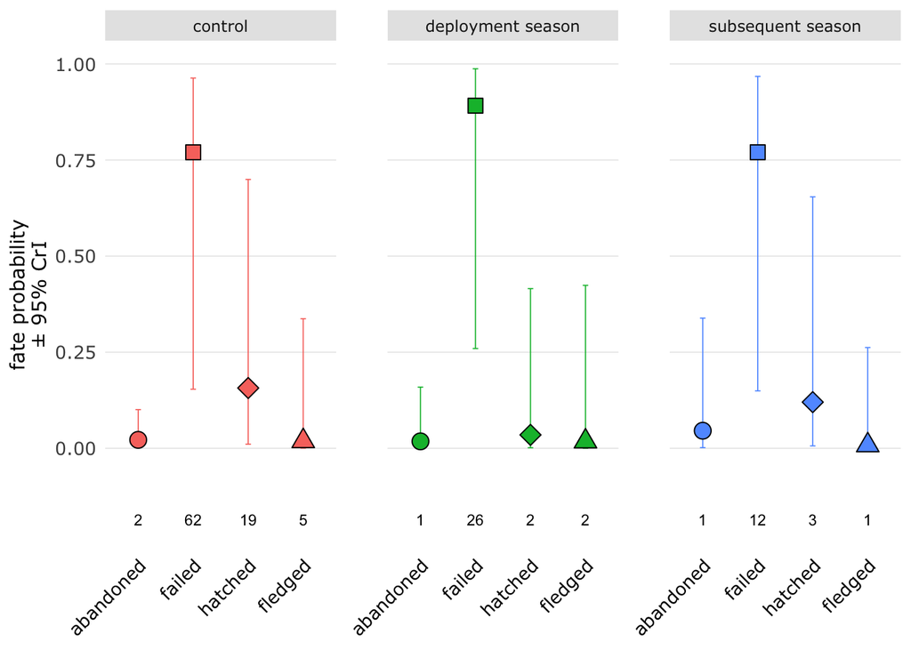

### modelling

```r
# set seed for reproducibility
set.seed(1234)

# Fit the mixed-effects multinomial logistic regression model
breed_brm <- brm(
  state ~ tag_type + (1 | season) + (1 | parent),
  data = breed_fates,
  family = categorical(link = "logit"),
  chains = 4,
  iter = 4000,
  control = list(adapt_delta = 0.99, max_treedepth = 15)
)

# consolidate results
stats_breed_brm <-
  list(mod = breed_brm,
       data = breed_fates)
```

# Apparent survival

### RMark data preparation

```r
ch <- read.csv(here("data/ch.csv"))

# Specify the states and create the dataframe for RMark
ch_processed <- process.data(ch, model = "Multistrata", groups = NULL)

ch_ddl <- make.design.data(ch_processed)

# Define parameter formulas
S.model <- list(formula = ~ stratum)  # Survival depends on the state
p.model <- list(formula = ~ stratum)  # Detection probability depends on the state
Psi.model.stratum <- list(formula = ~ -1 + stratum)
Psi.model.stratumto <- list(formula = ~ -1 + stratum:tostratum)
Psi.model.stratumtotime <- list(formula = ~ -1 + stratum : tostratum : time)  # Transition probabilities depend on the state and destination state
```

### RMark modelling

```r
model.list <- create.model.list("Multistrata")
surv.results <- mark.wrapper(model.list, data = ch_processed, ddl = ch_ddl,
                             threads = 4, brief = TRUE, delete = TRUE)
```

# Figure 2 - multi-panelled plot of all results

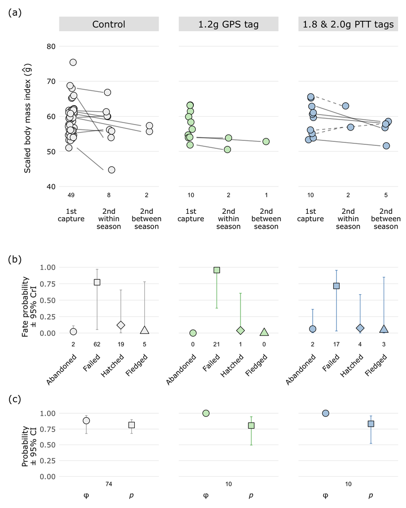

# Behavioural Observations

### data summary

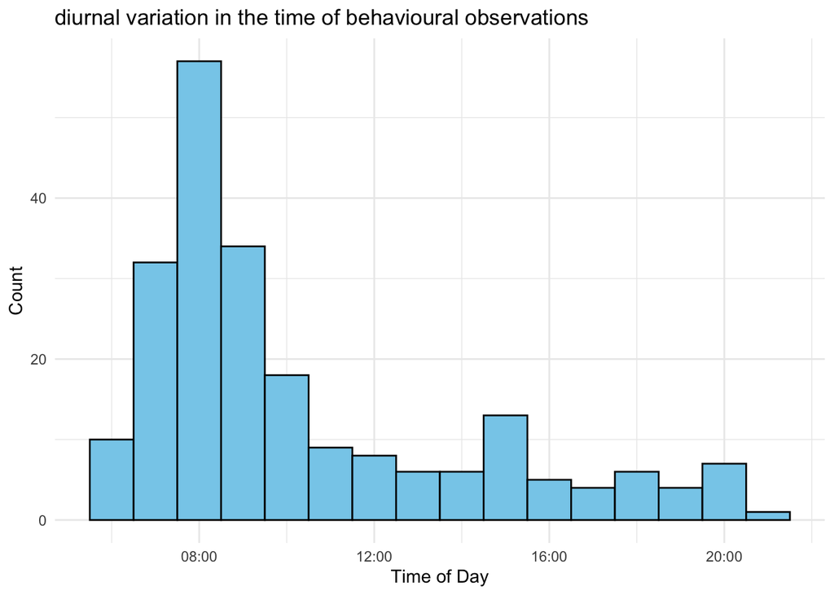

summary of behavioural observations

| tagged | n_obs |
| --- | --- |
| untagged | 76 |
| tagged | 148 |

### energy budget estimation

Table 5: Morrier and McNeil (1991). Time-activity budgets of Wilson's and Semipalmated Plovers in a tropical environment

| avg_prop_Feeding | 12.0340219 |
| --- | --- |
| avg_prop_Preening | 1.1922180 |
| avg_prop_Resting | 35.7261638 |
| avg_prop_Flight | 1.1573963 |
| avg_prop_Walking | 0.6282573 |
| avg_prop_Fight | 0.0553076 |
| avg_prop_Ground_Display | 0.1514821 |
| avg_prop_Alert | 2.0594441 |
| avg_prop_Running | 0.1839188 |
| avg_prop_Nocturnal_Resting | 46.8075087 |

### modelling

```r
inc_brood_model <-
  glmer(inc_brood ~ tagged + sin_time + cos_time + (1 | bird),
        data = behav, family = binomial)
```

Fixed Effects of the GLMM on incubation & brooding behaviour

| effect | term | estimate | std.error | statistic | p.value |
| --- | --- | --- | --- | --- | --- |
| fixed | (Intercept) | 43.355 | 15.721 | 2.758 | 0.006 |
| fixed | taggedY | 0.030 | 0.488 | 0.061 | 0.952 |
| fixed | sin_time | -3.004 | 1.254 | -2.396 | 0.017 |
| fixed | cos_time | -6.464 | 2.217 | -2.916 | 0.004 |

```r
walk_model <-
  glmer(walk ~ tagged + sin_time + cos_time + (1 | bird),
        data = behav, family = binomial)
```

Fixed Effects of the GLMM on walking behaviour

| effect | term | estimate | std.error | statistic | p.value |
| --- | --- | --- | --- | --- | --- |
| fixed | (Intercept) | -20.247 | 22.829 | -0.887 | 0.375 |
| fixed | taggedY | 0.691 | 0.783 | 0.883 | 0.377 |
| fixed | sin_time | 1.586 | 1.963 | 0.808 | 0.419 |
| fixed | cos_time | 3.336 | 3.164 | 1.054 | 0.292 |

```r
feed_model <-
  glmer(feed ~ tagged + sin_time + cos_time + (1 | bird),
        data = behav, family = binomial)
```

Fixed Effects of the GLMM on feeding behaviour

| effect | term | estimate | std.error | statistic | p.value |
| --- | --- | --- | --- | --- | --- |
| fixed | (Intercept) | 14.710 | 12.465 | 1.180 | 0.238 |
| fixed | taggedY | -0.398 | 0.301 | -1.324 | 0.186 |
| fixed | sin_time | -1.373 | 1.023 | -1.342 | 0.180 |
| fixed | cos_time | -2.066 | 1.746 | -1.183 | 0.237 |

```r
fly_model <-
  glmer(fly ~ tagged + sin_time + cos_time + (1 | bird),
        data = behav, family = binomial)
```

Fixed Effects of the GLMM on flying behaviour

| effect | term | estimate | std.error | statistic | p.value |
| --- | --- | --- | --- | --- | --- |
| fixed | (Intercept) | 1.664 | 17.726 | 0.094 | 0.925 |
| fixed | taggedY | 0.946 | 0.738 | 1.282 | 0.200 |
| fixed | sin_time | 0.107 | 1.491 | 0.072 | 0.943 |
| fixed | cos_time | -0.931 | 2.473 | -0.376 | 0.707 |

# Movements and tag operation

summary of deployment duration (weeks)

| tag_type | mean | max | min |
| --- | --- | --- | --- |
| GPS | 53.92857 | 60.71429 | 50.5714286 |
| PTT | 42.05357 | 57.14286 | 0.1428571 |

summary of fixes obtained per week

| tag_type | GPS | PTT |
| --- | --- | --- |
| mean | 0.6310789 | 11.3666695 |
| sd | 0.1959389 | 9.4714222 |
| min | 0.389518 | 2.061186 |
| max | 0.9462716 | 35.3164070 |

summary of total number of fixes acquired

| tag_type | total_points |
| --- | --- |
| GPS | 104 |
| PTT | 5544 |

summary of operational duration (weeks)

| tag_type | mean | sd | min | max |
| --- | --- | --- | --- | --- |
| GPS | 26.99767 | 11.04417 | 13.98582 | 39.71011 |
| PTT | 44.57389 | 30.31189 | 3.88126 | 91.51782 |

### plot of tag data collected over time

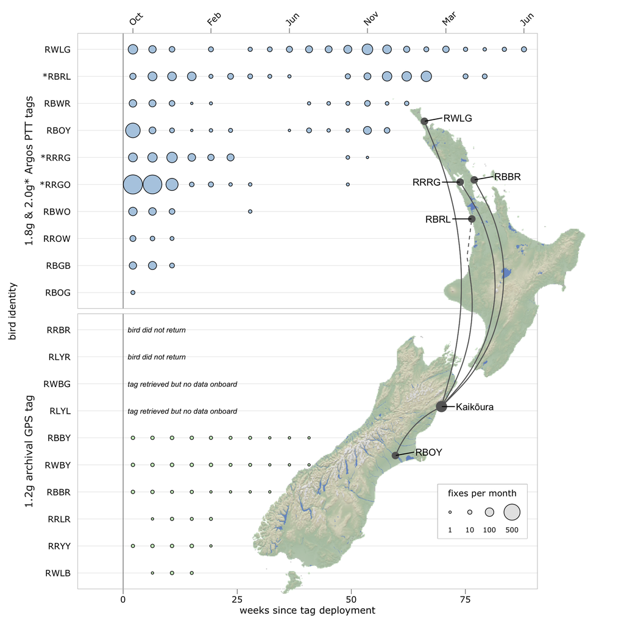

# Supplementary Analysis

## Breeding status and outcome (pairs)

#### summary of pair breeding fate data

number of mates and tag-type treatments over the three-year period

```r
breed_fates_wide %>%
  filter(parent_2 != "unkn") %>%
  group_by(parent_1) %>%
  summarise(n_mates = n_distinct(parent_2),
            n_combos = n_distinct(tag_type_combo)) %>%
  arrange(desc(n_mates))
```

```
# A tibble: 21 × 3
   parent_1 n_mates n_combos
   <chr>      <int>    <int>
 1 RBBY           2        1
 2 RBOG           2        1
 3 RBOY           2        1
 4 RBGB           1        1
 5 RBRL           1        1
 6 RBWR           1        1
 7 RLYL           1        2
 8 RRBB           1        1
 9 RRBG           1        1
10 RRBR           1        1
# ℹ 11 more rows
```

number distinct nesting attempts with different treatment combinations

```r
breed_fates_wide %>%
  group_by(tag_type_combo) %>%
  summarise(n_nests = n_distinct(nest_id))
```

```
# A tibble: 5 × 2
  tag_type_combo  n_nests
  <chr>             <int>
1 GPS-GPS               5
2 GPS-control          17
3 PTT-PTT               8
4 PTT-control          18
5 control-control      69
```

proportion of nests of different fates

```r
breed_fates_wide %>%
  dplyr::select(nest_id, state) %>%
  distinct() %>%
  group_by(state) %>%
  summarise(n_nests = n()/117)
```

```
# A tibble: 4 × 2
  state  n_nests
  <chr>    <dbl>
1 aband   0.0256
2 brood   0.171
3 fail    0.744
4 fledge  0.0598
```

### modelling

```r
breed_pair_brm_ <- brm(
  state ~ tag_type_combo + (1 | season),
  data = breed_fates_wide,
  family = categorical(link = "logit"),
  chains = 4,
  iter = 4000,
  control = list(adapt_delta = 0.99, max_treedepth = 15)
)

stats_breed_pair_brm <-
  list(mod = breed_pair_brm_,
       data = breed_fates_wide)
```

#### supplementary figure 1

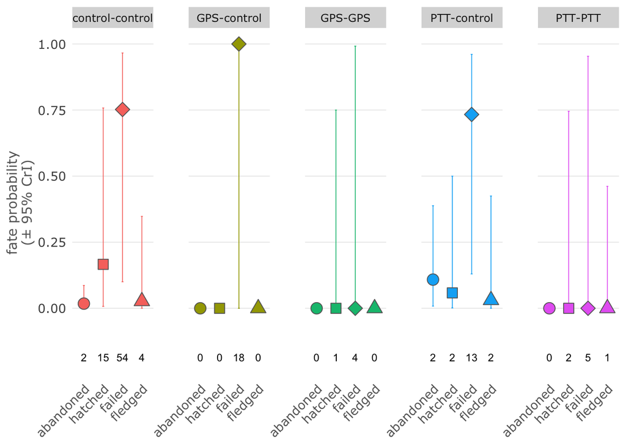